# Suicide Prevention - Data Science For Business Final Project

March 17, 2019

## Ideation

Suicide is an international plague which impacts not only the victim, but the family and friends of the victim. **What if we could use data science to help predict people at risk of suicide to target mental health resources?**

[figure not shown]

## Data Used

The data used for this work was found on the Kaggle website: https://www.kaggle.com/russellyates88/suicide-rates-overview-1985-to-2016#master.csv

It contains data from 1985 to 2016 with socio-economic information with suicide rates by year and country. The ultimate sources of the information compiled on the Kaggle website follow:

- United Nations Development Program.
- World Bank
- Suicide in the Twenty-First Century (also on Kaggle)
- World Health Organization

## Architecture

The architecture for my work on this project is relatively simple. I don't have access to Visio, so I was unable to draw a nice picture. However, the following was done from an architectural standpoint:

- Retrieve .csv file from the internet
- Pull in .csv file into Rstudio
- Pull in .csv file into Microsoft Power BI
- Extract data from Rstudio into excel for massaging, then reimport into RStudio

## Data Analysis

Use Microsoft Power BI to get a sense of the impact of Countries and age on the Suicide rates.

[figure not shown]

## Data Analysis

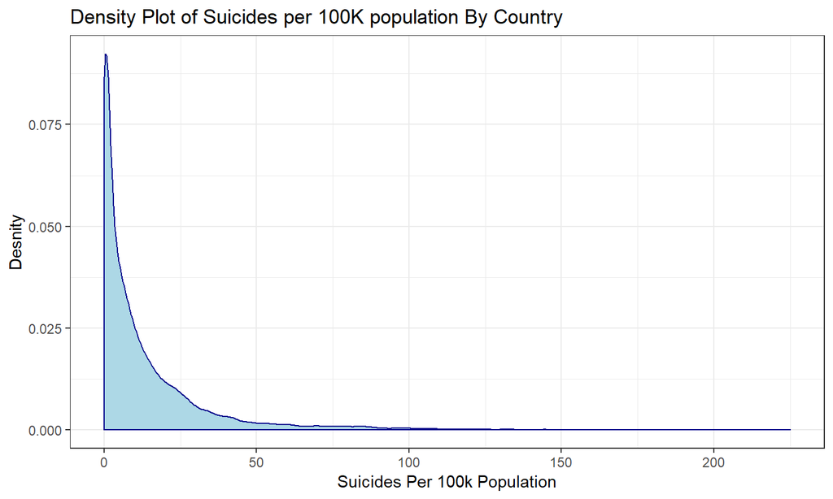

###### Min = 0 | 1st Qu. = .92 | Median = 5.99 | Mean = 12.82, 3rd Qu. = 16.62 | Max = 224.97

## Data Analysis

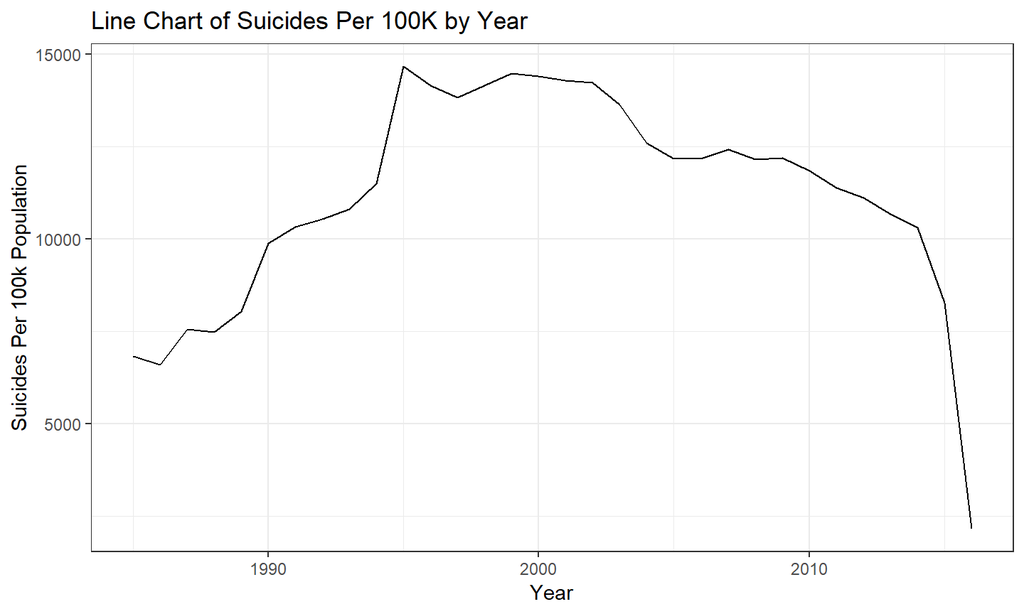

## Data Analysis

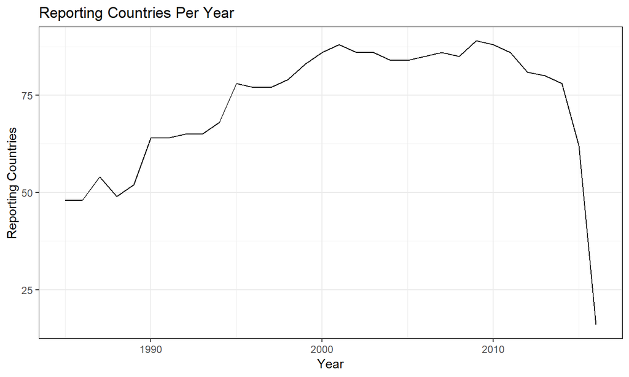

## Data Analysis

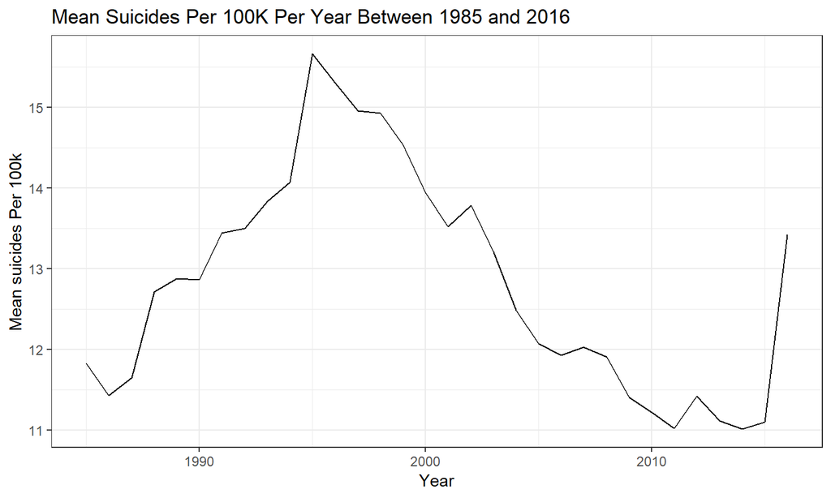

## Data Analysis

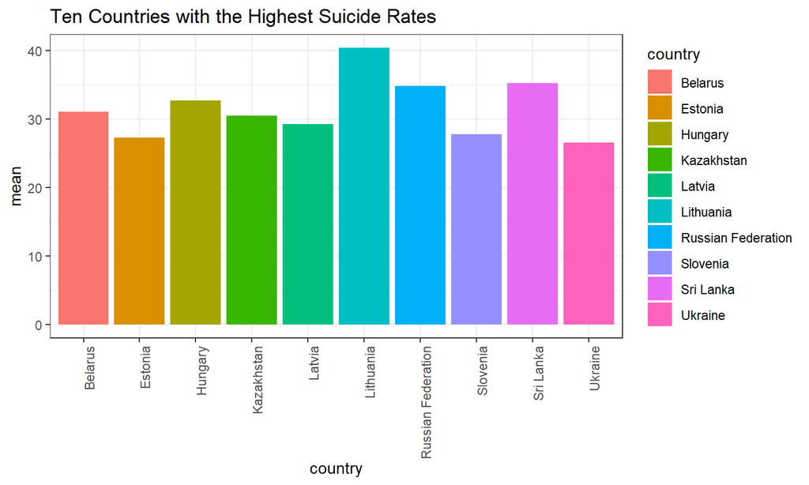

## Data Analysis

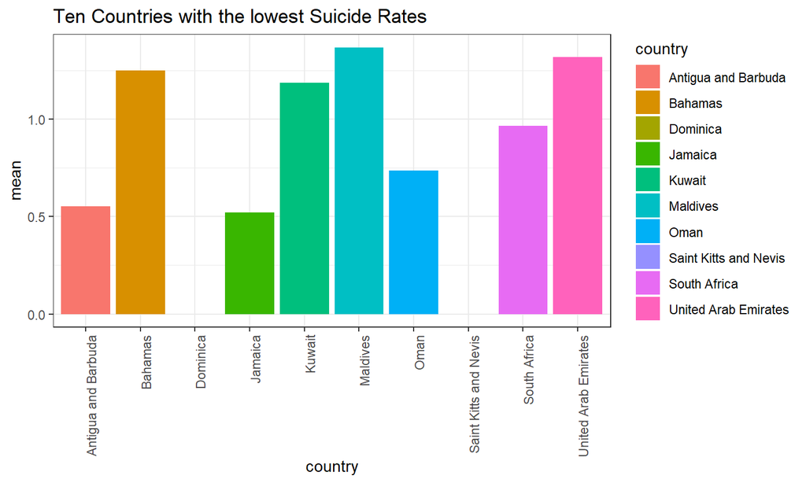

## Data Analysis

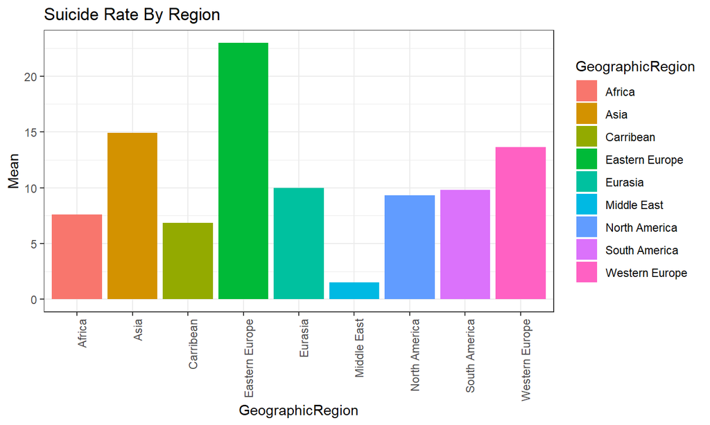

## Data Analysis

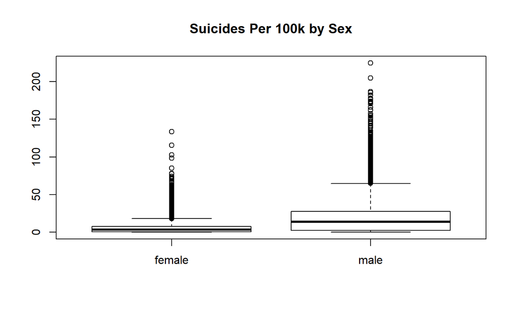

## Data Analysis

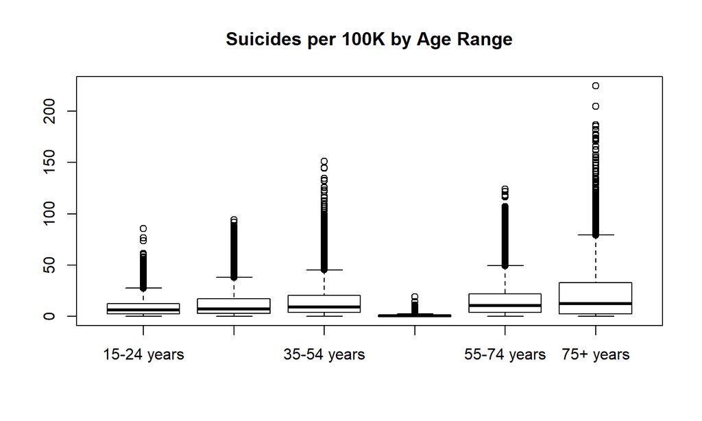

## Data Analysis

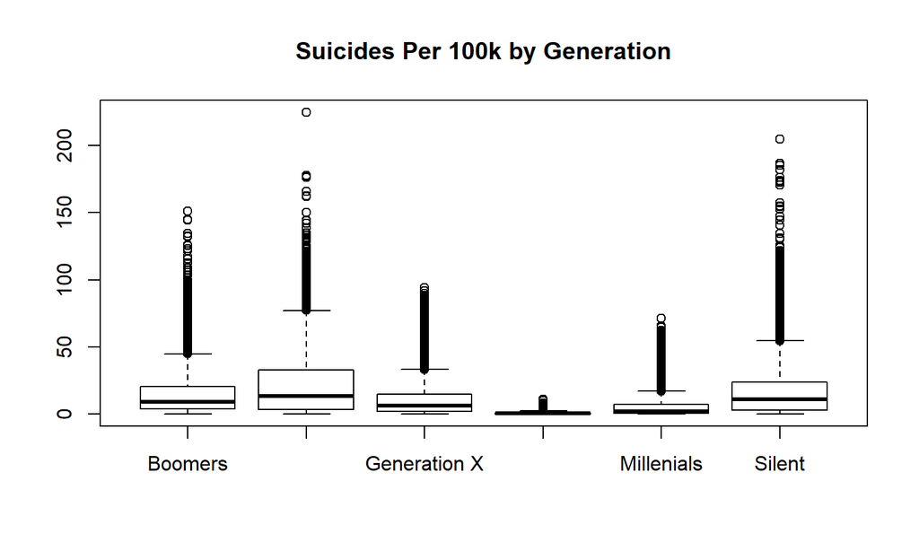

## Data Analysis

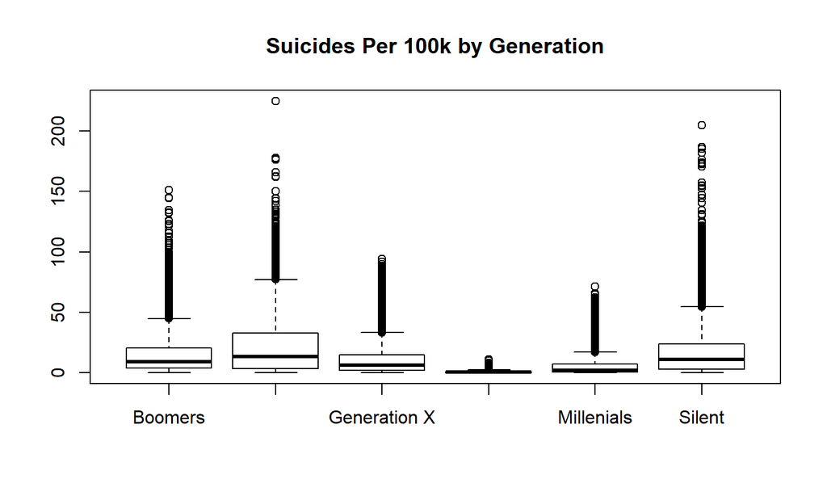

## Data Analysis

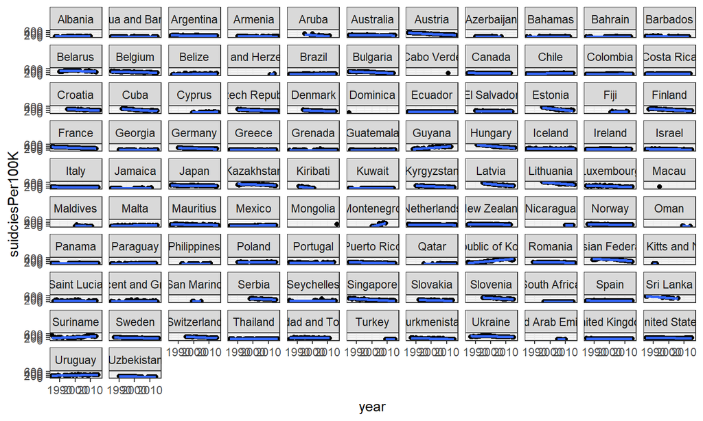

## Data Analysis

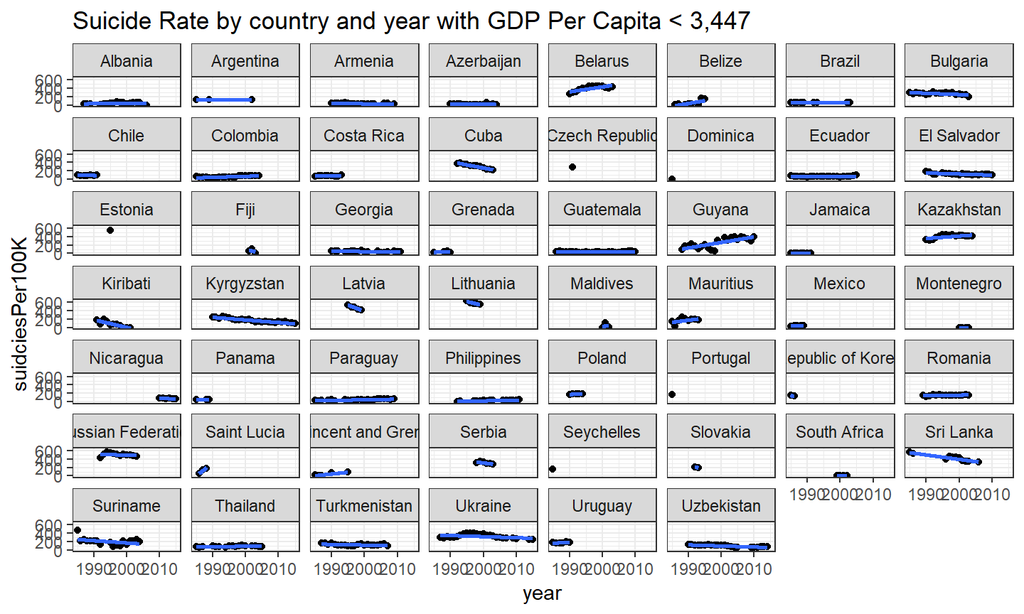

## Data Analysis

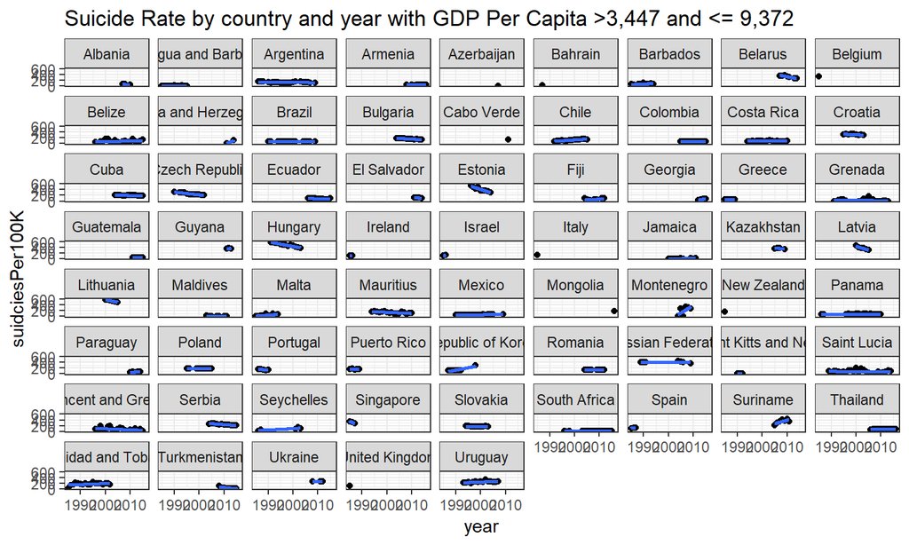

## Data Analysis

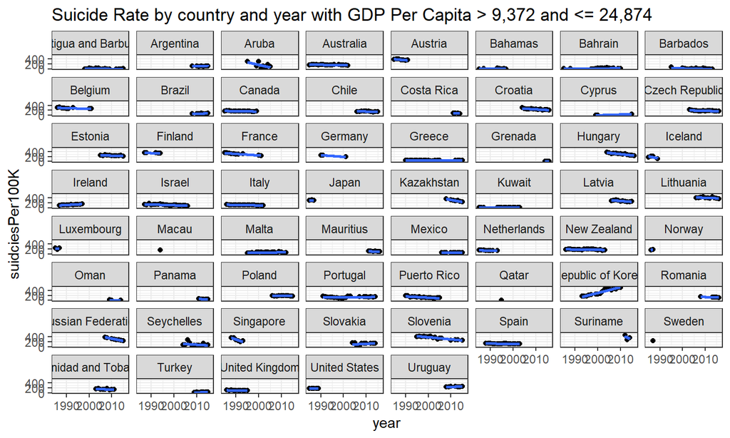

## Data Analysis

[figure not shown]

## Data Analysis

```
Warning: Removed 19456 rows containing missing values (geom_point).
```

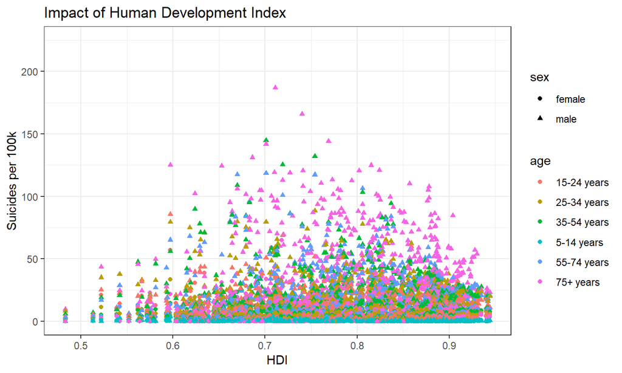

## Data Analysis

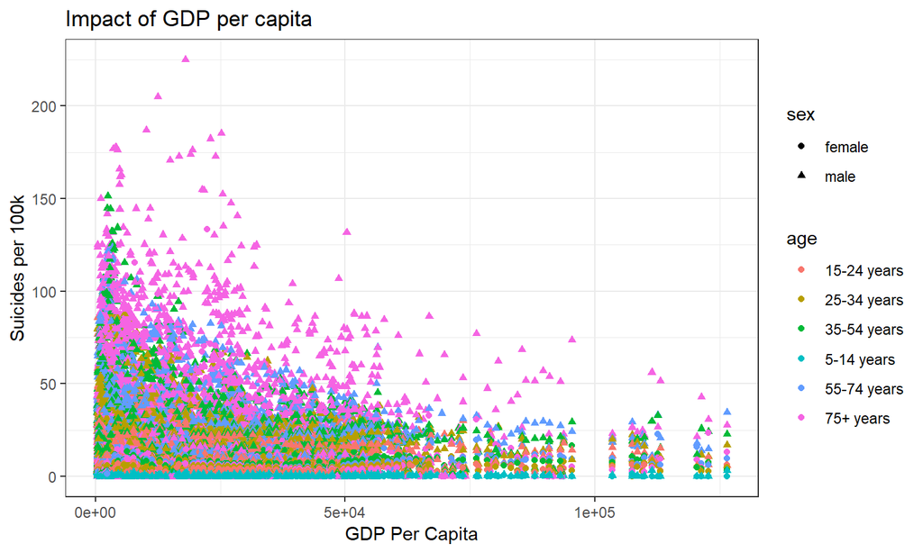

## Data Analysis

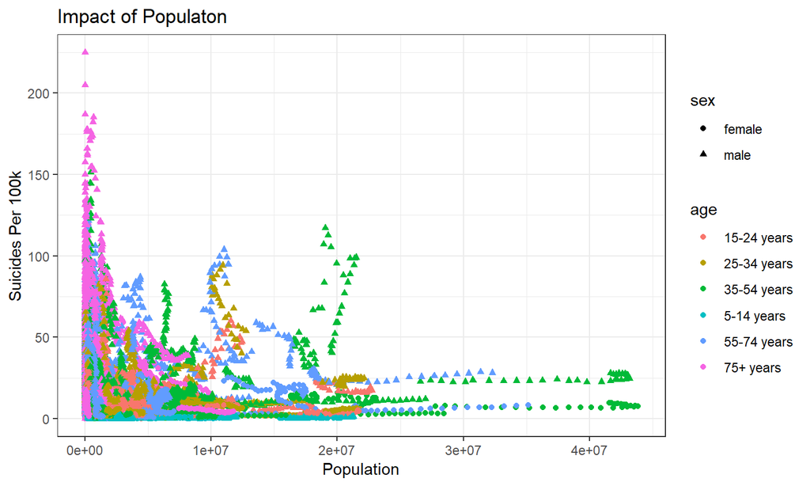

## Data Analysis

[figure not shown]

## Data Dictionary

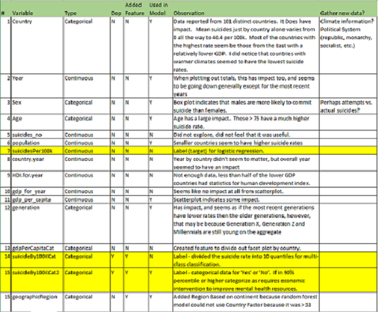

## Decision Tree

Use decision tree with cross fold validation with 70% - 30% split between training and testing data

- 10 fold
- Use Information Gain Criterion
- Use Gini Criterion

## Decision Tree Classifier With IG Criterion

```
          Reference
Prediction    A    B
         A  502  183
         B  332 7328
```

```
      Accuracy          Kappa  AccuracyLower  AccuracyUpper   AccuracyNull
  9.382864e-01   6.273738e-01   9.329087e-01   9.433555e-01   9.000599e-01
AccuracyPValue  McnemarPValue
  1.059757e-35   6.953386e-11
```

## D-Tree Classifier With IG Criterion

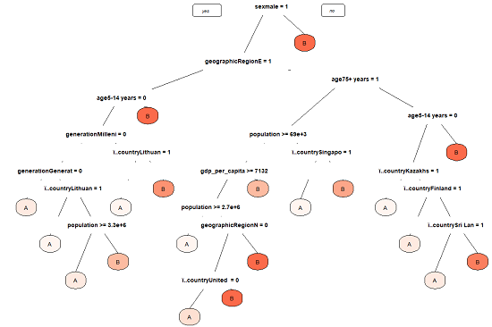

## Decision Tree Classifier with Gini Criterion

```
          Reference
Prediction    A    B
         A  468  131
         B  366 7380
```

```
      Accuracy          Kappa  AccuracyLower  AccuracyUpper   AccuracyNull
  9.404434e-01   6.215559e-01   9.351501e-01   9.454265e-01   9.000599e-01
AccuracyPValue  McnemarPValue
  5.875253e-40   8.979970e-26
```

## D-Tree Classifier With Gini Criterion

[figure not shown]

## Thank You

- Code can be found on github: https://github.com/mdmeschi72/suicidePrevention
- Questions?